# Librairies 📚

```python
# =========================
# Standard library
# =========================
import os
import sys
import time
import math
import re
import importlib

# =========================
# Data / scientific stack
# =========================
import numpy as np
import pandas as pd

# =========================
# Visualisation
# =========================
import matplotlib.pyplot as plt
import seaborn as sns
import missingno as msno

# =========================
# Stats
# =========================
import scipy.stats as stats
from scipy.stats import kruskal
import pingouin as pg
from statsmodels.stats.outliers_influence import variance_inflation_factor

from dython.nominal import (
    associations,
    correlation_ratio,  # eta²
    cramers_v,          # V de Cramér
    theils_u            # Alternative asymétrique
)

# =========================
# Machine Learning
# =========================
import lightgbm as lgb

from xgboost import XGBRegressor

from sklearn.compose import ColumnTransformer
from sklearn.dummy import DummyRegressor
from sklearn.ensemble import RandomForestRegressor
from sklearn.impute import SimpleImputer
from sklearn.inspection import permutation_importance
from sklearn.linear_model import LinearRegression, ElasticNet
from sklearn.metrics import (
    mean_absolute_error,
    mean_squared_error,
    mean_squared_log_error,
    r2_score,
)
from sklearn.model_selection import train_test_split, GridSearchCV, cross_validate
from sklearn.pipeline import Pipeline
from sklearn.preprocessing import (
    LabelEncoder,
    MultiLabelBinarizer,
    OneHotEncoder,
    RobustScaler,
    StandardScaler,
)
from sklearn.svm import SVR

# =========================
# Local imports (src/)
# =========================
sys.path.append(os.path.abspath(".."))  # si notebook dans /notebooks

import src.outliers_function as of
import src.association_report_function as ar
import src.analyse_bivariee as ab
import src.modeles_comparator as mdl
import src.tunning_parameter as tp
import src.outliers_treatment as ot

importlib.reload(of)

# =========================
# Pandas display options
# =========================
pd.set_option("display.max_columns", None)
pd.options.display.float_format = "{:,.2f}".format
```

# Import de la table 🪑

```python
building_consumption = pd.read_csv("/home/maxime/projects/building-energy-Seattle/data/external/2016_Building_Energy_Benchmarking.csv")
```

```python
# On regarde comment un batiment est défini dans ce jeu de données
building_consumption.head()
```

|  | OSEBuildingID | DataYear | BuildingType | PrimaryPropertyType | PropertyName | Address | City | State | ZipCode | TaxParcelIdentificationNumber | CouncilDistrictCode | Neighborhood | Latitude | Longitude | YearBuilt | NumberofBuildings | NumberofFloors | PropertyGFATotal | PropertyGFAParking | PropertyGFABuilding(s) | ListOfAllPropertyUseTypes | LargestPropertyUseType | LargestPropertyUseTypeGFA | SecondLargestPropertyUseType | SecondLargestPropertyUseTypeGFA | ThirdLargestPropertyUseType | ThirdLargestPropertyUseTypeGFA | YearsENERGYSTARCertified | ENERGYSTARScore | … |
| --- | --- | --- | --- | --- | --- | --- | --- | --- | --- | --- | --- | --- | --- | --- | --- | --- | --- | --- | --- | --- | --- | --- | --- | --- | --- | --- | --- | --- | --- | --- |
| 0 | 1 | 2016 | NonResidential | Hotel | Mayflower park hotel | 405 Olive way | Seattle | WA | 98,101.00 | 0659000030 | 7 | DOWNTOWN | 47.61 | -122.34 | 1927 | 1.00 | 12 | 88434 | 0 | 88434 | Hotel | Hotel | 88,434.00 | NaN | NaN | NaN | NaN | NaN | 60.00 | … |
| 1 | 2 | 2016 | NonResidential | Hotel | Paramount Hotel | 724 Pine street | Seattle | WA | 98,101.00 | 0659000220 | 7 | DOWNTOWN | 47.61 | -122.33 | 1996 | 1.00 | 11 | 103566 | 15064 | 88502 | Hotel, Parking, Restaurant | Hotel | 83,880.00 | Parking | 15,064.00 | Restaurant | 4,622.00 | NaN | 61.00 | … |
| 2 | 3 | 2016 | NonResidential | Hotel | 5673-The Westin Seattle | 1900 5th Avenue | Seattle | WA | 98,101.00 | 0659000475 | 7 | DOWNTOWN | 47.61 | -122.34 | 1969 | 1.00 | 41 | 956110 | 196718 | 759392 | Hotel | Hotel | 756,493.00 | NaN | NaN | NaN | NaN | NaN | 43.00 | … |
| 3 | 5 | 2016 | NonResidential | Hotel | HOTEL MAX | 620 STEWART ST | Seattle | WA | 98,101.00 | 0659000640 | 7 | DOWNTOWN | 47.61 | -122.34 | 1926 | 1.00 | 10 | 61320 | 0 | 61320 | Hotel | Hotel | 61,320.00 | NaN | NaN | NaN | NaN | NaN | 56.00 | … |
| 4 | 8 | 2016 | NonResidential | Hotel | WARWICK SEATTLE HOTEL (ID8) | 401 LENORA ST | Seattle | WA | 98,121.00 | 0659000970 | 7 | DOWNTOWN | 47.61 | -122.34 | 1980 | 1.00 | 18 | 175580 | 62000 | 113580 | Hotel, Parking, Swimming Pool | Hotel | 123,445.00 | Parking | 68,009.00 | Swimming Pool | 0.00 | NaN | 75.00 | … |

```python
# On regarde le nombre de valeurs manquantes par colonne ainsi que leur type
building_consumption.info()
```

```
<class 'pandas.DataFrame'>
RangeIndex: 3376 entries, 0 to 3375
Data columns (total 46 columns):
 #   Column                           Non-Null Count  Dtype
---  ------                           --------------  -----
 0   OSEBuildingID                    3376 non-null   int64
 1   DataYear                         3376 non-null   int64
 2   BuildingType                     3376 non-null   str
 3   PrimaryPropertyType              3376 non-null   str
 4   PropertyName                     3376 non-null   str
 5   Address                          3376 non-null   str
 6   City                             3376 non-null   str
 7   State                            3376 non-null   str
 8   ZipCode                          3360 non-null   float64
 9   TaxParcelIdentificationNumber    3376 non-null   str
```

[output cut: 38 more lines]

```python
df = building_consumption.copy()
```

# Etape 1 - Analyse exploratoire 🕵️‍♀️

A réaliser :

- Une analyse descriptive des données, y compris une explication du sens des colonnes gardées, des arguments derrière la suppression de lignes ou de colonnes, des statistiques descriptives et des visualisations pertinentes.

Qelques pistes d'analyse :

- Identifier les colonnes avec une majorité de valeurs manquantes ou constantes en utilisant la méthode value_counts() de Pandas
- Mettre en evidence les différences entre les immeubles mono et multi-usages
- Utiliser des pairplots et des boxplots pour faire ressortir les outliers ou des batiments avec des valeurs peu cohérentes d'un point de vue métier

Pour vous inspirer, ou comprendre l'esprit recherché dans une analyse exploratoire, vous pouvez consulter ce notebook en ligne : https://www.kaggle.com/code/pmarcelino/comprehensive-data-exploration-with-python. Il ne s'agit pas d'un modèle à suivre à la lettre ni d'un template d'analyses attendues pour ce projet.

## Nettoyage des données

```python
df.shape
```

```
(3376, 46)
```

### Valeurs nulles

```python
df.isna().mean().sort_values(ascending=False).head(15)
```

```
Comments                          1.00
Outlier                           0.99
YearsENERGYSTARCertified          0.96
ThirdLargestPropertyUseType       0.82
ThirdLargestPropertyUseTypeGFA    0.82
SecondLargestPropertyUseType      0.50
SecondLargestPropertyUseTypeGFA   0.50
ENERGYSTARScore                   0.25
LargestPropertyUseTypeGFA         0.01
LargestPropertyUseType            0.01
ZipCode                           0.00
ListOfAllPropertyUseTypes         0.00
Electricity(kWh)                  0.00
SourceEUIWN(kBtu/sf)              0.00
GHGEmissionsIntensity             0.00
dtype: float64
```

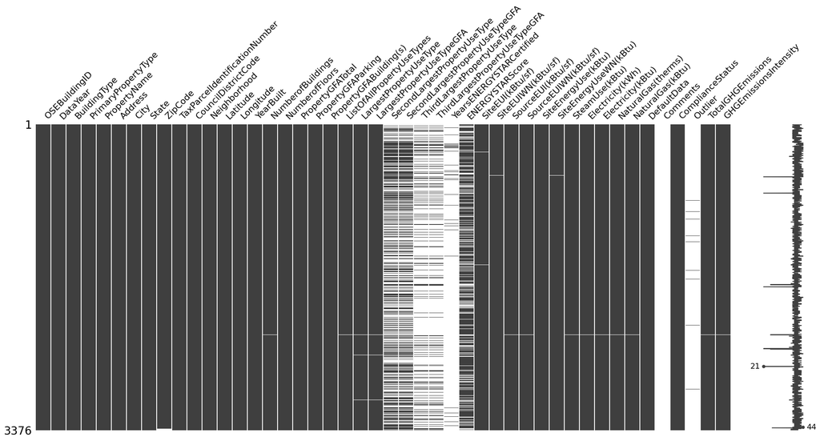

```python
msno.matrix(df)
```

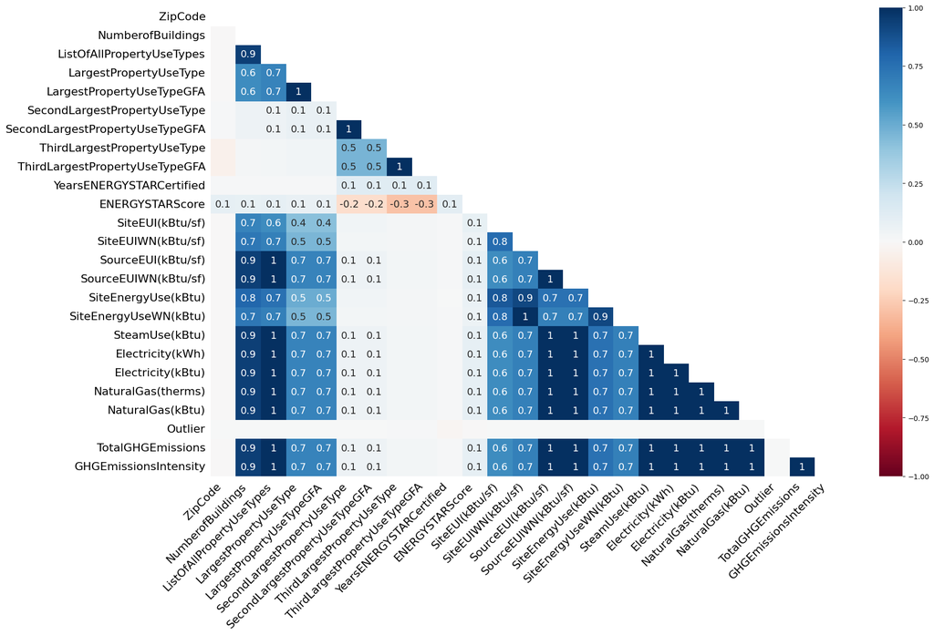

```python
msno.heatmap(df)
```

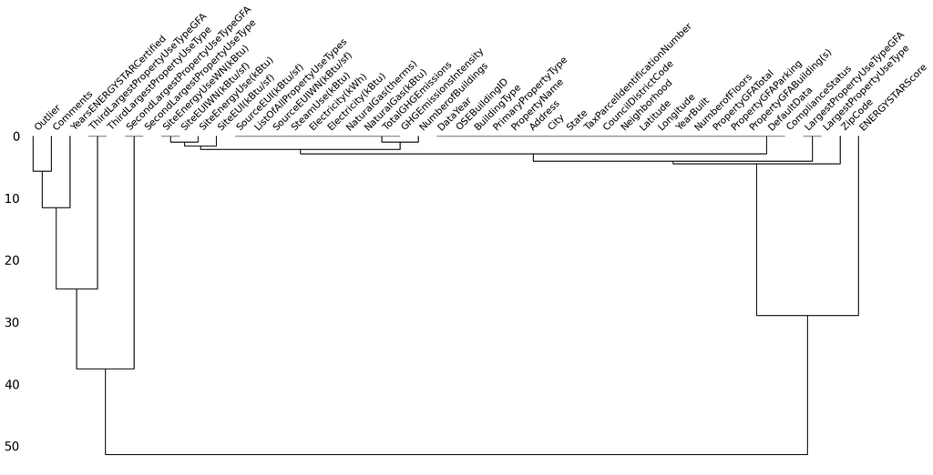

```python
msno.dendrogram(df)
```

#### Colonne Comments ❌

```python
df.drop(columns="Comments",inplace=True)
```

#### Colonne Outliers ✅

```python
df[df["Outlier"].notna()]["Outlier"].value_counts()
# la colonne outliers a beaucoup de valeur vide mais elle a toutefois son utilité. Je vais la garder pour le moment.
```

```
Outlier
Low outlier     23
High outlier     9
Name: count, dtype: int64
```

#### Colonne YearsENERGYSTARCertified ❌ (création année's + nb_certification) ✅

```python
df[df["YearsENERGYSTARCertified"].notna()].sample()
# la colonne très intéressante, il faut :
# - Séparer les années tous les 4 caractères
# - Créer les dummies par année
```

|  | OSEBuildingID | DataYear | BuildingType | PrimaryPropertyType | PropertyName | Address | City | State | ZipCode | TaxParcelIdentificationNumber | CouncilDistrictCode | Neighborhood | Latitude | Longitude | YearBuilt | NumberofBuildings | NumberofFloors | PropertyGFATotal | PropertyGFAParking | PropertyGFABuilding(s) | ListOfAllPropertyUseTypes | LargestPropertyUseType | LargestPropertyUseTypeGFA | SecondLargestPropertyUseType | SecondLargestPropertyUseTypeGFA | ThirdLargestPropertyUseType | ThirdLargestPropertyUseTypeGFA | YearsENERGYSTARCertified | ENERGYSTARScore | … |
| --- | --- | --- | --- | --- | --- | --- | --- | --- | --- | --- | --- | --- | --- | --- | --- | --- | --- | --- | --- | --- | --- | --- | --- | --- | --- | --- | --- | --- | --- | --- |
| 3199 | 49776 | 2016 | NonResidential | Large Office | Market Place Tower | 2025 1st Avenue | Seattle | WA | 98,121.00 | 1977200471 | 7 | DOWNTOWN | 47.61 | -122.34 | 1988 | 1.00 | 13 | 354086 | 149326 | 204760 | Data Center, Multifamily Housing, Office, Othe... | Office | 193,393.00 | Parking | 149,326.00 | Multifamily Housing | 38,225.00 | 201620092008 | 88.00 | … |

```python
def split_years(x):
    if pd.isna(x):
        return []
    x = str(x)
    return [x[i:i+4] for i in range(0, len(x), 4)]

df["Years_list"] = df["YearsENERGYSTARCertified"].apply(split_years)
```

```python
df[df["YearsENERGYSTARCertified"].notna()][["YearsENERGYSTARCertified", "Years_list"]]
```

|  | YearsENERGYSTARCertified | Years_list |
| --- | --- | --- |
| 37 | 2016 | [2016] |
| 44 | 2016 | [2016] |
| 53 | 2014 | [2014] |
| 116 | 2016 | [2016] |
| 137 | 2016 | [2016] |
| ... | ... | ... |
| 3281 | 20172016 | [2017, 2016] |
| 3293 | 2017 | [2017] |
| 3304 | 20172016 | [2017, 2016] |
| 3317 | 2017 | [2017] |
| 3325 | 20172016 | [2017, 2016] |

119 rows × 2 columns

```python
# Créer les dummies (One-hot encoding multi-label)
#mlb = MultiLabelBinarizer()

#years_dummies = pd.DataFrame(
#    mlb.fit_transform(df["Years_list"]), # type: ignore
#    columns=mlb.classes_,
#    index=df.index
#) # type: ignore
#years_dummies = years_dummies.astype(int)
```

```python
#df = pd.concat([df, years_dummies], axis=1)
```

```python
df["nb_certifications"] = df["Years_list"].apply(len)
df.drop(columns=["Years_list","YearsENERGYSTARCertified"],inplace=True)
```

```python
df.head(2)
```

|  | OSEBuildingID | DataYear | BuildingType | PrimaryPropertyType | PropertyName | Address | City | State | ZipCode | TaxParcelIdentificationNumber | CouncilDistrictCode | Neighborhood | Latitude | Longitude | YearBuilt | NumberofBuildings | NumberofFloors | PropertyGFATotal | PropertyGFAParking | PropertyGFABuilding(s) | ListOfAllPropertyUseTypes | LargestPropertyUseType | LargestPropertyUseTypeGFA | SecondLargestPropertyUseType | SecondLargestPropertyUseTypeGFA | ThirdLargestPropertyUseType | ThirdLargestPropertyUseTypeGFA | ENERGYSTARScore | SiteEUI(kBtu/sf) | … |
| --- | --- | --- | --- | --- | --- | --- | --- | --- | --- | --- | --- | --- | --- | --- | --- | --- | --- | --- | --- | --- | --- | --- | --- | --- | --- | --- | --- | --- | --- | --- |
| 0 | 1 | 2016 | NonResidential | Hotel | Mayflower park hotel | 405 Olive way | Seattle | WA | 98,101.00 | 0659000030 | 7 | DOWNTOWN | 47.61 | -122.34 | 1927 | 1.00 | 12 | 88434 | 0 | 88434 | Hotel | Hotel | 88,434.00 | NaN | NaN | NaN | NaN | 60.00 | 81.70 | … |
| 1 | 2 | 2016 | NonResidential | Hotel | Paramount Hotel | 724 Pine street | Seattle | WA | 98,101.00 | 0659000220 | 7 | DOWNTOWN | 47.61 | -122.33 | 1996 | 1.00 | 11 | 103566 | 15064 | 88502 | Hotel, Parking, Restaurant | Hotel | 83,880.00 | Parking | 15,064.00 | Restaurant | 4,622.00 | 61.00 | 94.80 | … |

#### Colonne "Second" et "Third" ✅

```python
df["nb_property_uses"] = (
    df["LargestPropertyUseType"].notna().astype(int) +
    df["SecondLargestPropertyUseType"].notna().astype(int) +
    df["ThirdLargestPropertyUseType"].notna().astype(int)
)
```

```python
df["nb_property_uses"].value_counts()
```

```
nb_property_uses
1    1677
2    1083
3     596
0      20
Name: count, dtype: int64
```

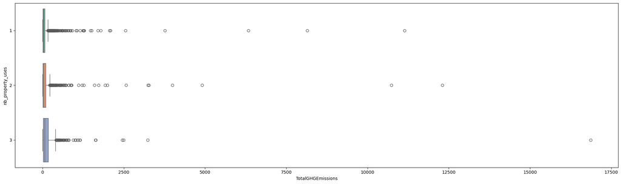

```python
plt.figure(figsize=(20, 6))
data = df[df["nb_property_uses"] > 0]
sns.boxplot(y="nb_property_uses", x="TotalGHGEmissions", data=data, orient="h", palette='Set2')
plt.tight_layout()
plt.show()
```

```python
df.groupby("nb_property_uses")["TotalGHGEmissions"].mean()
```

```
nb_property_uses
0    65.84
1    94.06
2   124.97
3   183.40
Name: TotalGHGEmissions, dtype: float64
```

```python
df.groupby("nb_property_uses")["TotalGHGEmissions"].median()
```

```
nb_property_uses
0   18.95
1   26.41
2   34.00
3   63.25
Name: TotalGHGEmissions, dtype: float64
```

#### Colonne ListOfAllPropertyUseTypes ✅ (création de nb_property_uses et is_mixed_use)

```python
df["nb_property_uses"] = (
    df["ListOfAllPropertyUseTypes"]
    .fillna("")  # évite les erreurs sur NaN
    .apply(lambda x: len([u.strip() for u in x.split(",") if u.strip() != ""]))
)
```

```python
df[["ListOfAllPropertyUseTypes", "nb_property_uses"]].head(10)
```

|  | ListOfAllPropertyUseTypes | nb_property_uses |
| --- | --- | --- |
| 0 | Hotel | 1 |
| 1 | Hotel, Parking, Restaurant | 3 |
| 2 | Hotel | 1 |
| 3 | Hotel | 1 |
| 4 | Hotel, Parking, Swimming Pool | 3 |
| 5 | Police Station | 1 |
| 6 | Hotel | 1 |
| 7 | Other - Entertainment/Public Assembly | 1 |
| 8 | Hotel | 1 |
| 9 | Multifamily Housing | 1 |

```python
df["is_mixed_use"] = (df["nb_property_uses"] > 1).astype(int)
```

### Supprimer les doublons 👥

```python
df.duplicated().sum()
```

```
np.int64(0)
```

```python
df["DefaultData"].value_counts(normalize=True)
```

```
DefaultData
False   0.97
True    0.03
Name: proportion, dtype: float64
```

```python
df["ComplianceStatus"].value_counts(normalize=True)
```

```
ComplianceStatus
Compliant                      0.95
Error - Correct Default Data   0.03
Non-Compliant                  0.01
Missing Data                   0.00
Name: proportion, dtype: float64
```

```python
df = df[df["DefaultData"] == False].copy()
df = df[df["ComplianceStatus"] == "Compliant"].copy()
df.drop(columns=["DefaultData","ComplianceStatus"])
df.shape, building_consumption.shape
```

```
((3211, 47), (3376, 46))
```

### Suppression des lignes avce des building hors "bâtiments non destinés à l’habitation"

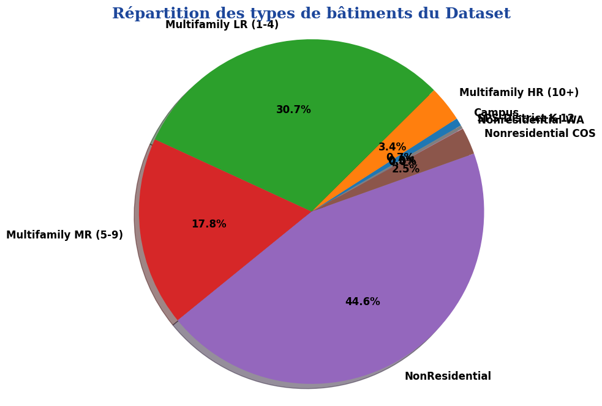

```python
building_type = df.groupby(by='BuildingType')['OSEBuildingID'].nunique()

font_title = {'family': 'serif',
              'color':  '#1d479b',
              'weight': 'bold',
              'size': 18,
             }

fig, ax = plt.subplots(figsize=(8,8))
ax.pie(building_type.values, labels=building_type.index,
       autopct='%1.1f%%', shadow=True, startangle=30,
       textprops=dict(color="black",size=12, weight="bold"))
ax.axis('equal')
ax.set_title("Répartition des types de bâtiments du Dataset", fontdict=font_title)
plt.show()
```

```python
df.loc[(df['BuildingType']=="NonResidential"),'PrimaryPropertyType'].value_counts()
```

```
PrimaryPropertyType
Small- and Mid-Sized Office    282
Other                          181
Warehouse                      178
Large Office                   164
Mixed Use Property             101
Retail Store                    85
Hotel                           75
Worship Facility                69
Distribution Center             51
Supermarket / Grocery Store     40
K-12 School                     38
Medical Office                  38
Self-Storage Facility           28
Residence Hall                  21
Senior Care Community           20
University                      17
Refrigerated Warehouse          12
Restaurant                      11
Hospital                        10
Laboratory                      10
Low-Rise Multifamily             1
Name: count, dtype: int64
```

```python
regex = re.compile(r'[\n\r\t]')
df['PrimaryPropertyType'] = (
    df['PrimaryPropertyType']
        .str.replace(r'[\n\r\t]', '', regex=True)
)
df.loc[(df['BuildingType']=="NonResidential"),'PrimaryPropertyType'].value_counts()
```

```
PrimaryPropertyType
Small- and Mid-Sized Office    282
Other                          181
Warehouse                      178
Large Office                   164
Mixed Use Property             101
Retail Store                    85
Hotel                           75
Worship Facility                69
Distribution Center             51
Supermarket / Grocery Store     40
K-12 School                     38
Medical Office                  38
Self-Storage Facility           28
Residence Hall                  21
Senior Care Community           20
University                      17
Refrigerated Warehouse          12
Restaurant                      11
Hospital                        10
Laboratory                      10
Low-Rise Multifamily             1
Name: count, dtype: int64
```

```python
val = [
    'NonResidential',
    'Nonresidential COS',
   "Campus",
    "Nonresidential WA",
    "'SPS-District K-12'"
]

df = df[df["BuildingType"].isin(val)]
```

### Suppresion des lignes avec des Outliers

```python
df = df[~df["Outlier"].isnull() == False]
df.drop('Outlier', axis=1, inplace=True)
```

### Suppression des colonnes avec toujours la même valeurs

```python
df.loc[:, df.nunique() == 1]
```

|  | DataYear | City | State | DefaultData | ComplianceStatus |
| --- | --- | --- | --- | --- | --- |
| 0 | 2016 | Seattle | WA | False | Compliant |
| 1 | 2016 | Seattle | WA | False | Compliant |
| 2 | 2016 | Seattle | WA | False | Compliant |
| 3 | 2016 | Seattle | WA | False | Compliant |
| 4 | 2016 | Seattle | WA | False | Compliant |
| ... | ... | ... | ... | ... | ... |
| 3370 | 2016 | Seattle | WA | False | Compliant |
| 3372 | 2016 | Seattle | WA | False | Compliant |
| 3373 | 2016 | Seattle | WA | False | Compliant |
| 3374 | 2016 | Seattle | WA | False | Compliant |
| 3375 | 2016 | Seattle | WA | False | Compliant |

1538 rows × 5 columns

```python
df = df.loc[:, df.nunique() > 1]
```

### Suppression des variables redondantes

```python
redundant_features = ['NaturalGas(therms)','Electricity(kWh)']
df.drop(redundant_features, axis=1, inplace=True)
```

```python
df.sample(5)
```

|  | OSEBuildingID | BuildingType | PrimaryPropertyType | PropertyName | Address | ZipCode | TaxParcelIdentificationNumber | CouncilDistrictCode | Neighborhood | Latitude | Longitude | YearBuilt | NumberofBuildings | NumberofFloors | PropertyGFATotal | PropertyGFAParking | PropertyGFABuilding(s) | ListOfAllPropertyUseTypes | LargestPropertyUseType | LargestPropertyUseTypeGFA | SecondLargestPropertyUseType | SecondLargestPropertyUseTypeGFA | ThirdLargestPropertyUseType | ThirdLargestPropertyUseTypeGFA | ENERGYSTARScore | SiteEUI(kBtu/sf) | SiteEUIWN(kBtu/sf) | SourceEUI(kBtu/sf) | SourceEUIWN(kBtu/sf) | … |
| --- | --- | --- | --- | --- | --- | --- | --- | --- | --- | --- | --- | --- | --- | --- | --- | --- | --- | --- | --- | --- | --- | --- | --- | --- | --- | --- | --- | --- | --- | --- |
| 3182 | 49725 | NonResidential | Other | VM Seattle Hospital & Medical Center - Jones P... | 1010 Spring St | 98,101.00 | 8590901075 | 3 | EAST | 47.61 | -122.33 | 2012 | 1.00 | 7 | 267470 | 0 | 267470 | Hospital (General Medical & Surgical), Other | Other | 160,482.00 | Hospital (General Medical & Surgical) | 106,988.00 | NaN | NaN | NaN | 159.20 | 159.70 | 363.70 | 361.40 | … |
| 3235 | 49867 | NonResidential | Large Office | Home Plate Center Bldg B | 1521 1ST AVE S | 98,134.00 | 7666207075 | 2 | GREATER DUWAMISH | 47.59 | -122.33 | 2014 | 1.00 | 7 | 333714 | 146687 | 187027 | Office, Parking | Office | 191,333.00 | Parking | 133,432.00 | NaN | NaN | NaN | 23.90 | 24.30 | 72.80 | 73.10 | … |
| 293 | 423 | NonResidential | Large Office | One Union Square | 600 University Street | 98,101.00 | 1976700155 | 7 | DOWNTOWN | 47.61 | -122.33 | 1980 | 1.00 | 36 | 794592 | 0 | 794592 | Office, Other, Parking | Office | 748,011.00 | Parking | 36,606.00 | Other | 9,975.00 | 96.00 | 35.20 | 36.10 | 108.70 | 111.40 | … |
| 501 | 682 | NonResidential | Other | West Seattle Fitness | 2629 SW Andover Street | 98,121.00 | 9358000300 | 1 | DELRIDGE | 47.57 | -122.37 | 2001 | 1.00 | 3 | 68763 | 11527 | 57236 | Other - Recreation, Parking, Swimming Pool | Other - Recreation | 50,000.00 | Parking | 11,527.00 | Swimming Pool | 0.00 | NaN | 180.60 | 191.90 | 343.10 | 355.00 | … |
| 3072 | 28053 | NonResidential | Worship Facility | (ID28053)CONGREGATION BETH SHALOM | 6800 35TH AVE NE | 98,115.00 | 4361200005 | 4 | NORTHEAST | 47.68 | -122.29 | 1955 | 1.00 | 1 | 29079 | 0 | 29079 | Worship Facility | Worship Facility | 29,079.00 | NaN | NaN | NaN | NaN | 78.00 | 29.60 | 32.00 | 67.80 | 70.30 | … |

### Suppresion des colonnes WN

Les suffixes WN : "Weather Normalized" - Ce sont les mesures normalisées avec les conditions climatiques. Dans le cadre de notre analyse, la météo ne rentrera pas en compte.

```python
def search_componant(df, suffix=None):
  componant = []
  for col in df.columns:
      if suffix in col:
        componant.append(col)
  return componant
```

```python
df.drop(search_componant(df,'WN'), axis=1, inplace=True)
```

## Analyse univariée

```python
df.describe().T
```

|  | count | mean | std | min | 25% | 50% | 75% | max |
| --- | --- | --- | --- | --- | --- | --- | --- | --- |
| OSEBuildingID | 1,538.00 | 16,527.60 | 13,835.26 | 1.00 | 604.25 | 21,182.50 | 24,619.00 | 50,226.00 |
| ZipCode | 1,525.00 | 98,116.66 | 18.56 | 98,006.00 | 98,104.00 | 98,109.00 | 98,125.00 | 98,199.00 |
| CouncilDistrictCode | 1,538.00 | 4.41 | 2.19 | 1.00 | 2.00 | 4.00 | 7.00 | 7.00 |
| Latitude | 1,538.00 | 47.62 | 0.05 | 47.51 | 47.59 | 47.61 | 47.65 | 47.73 |
| Longitude | 1,538.00 | -122.33 | 0.02 | -122.41 | -122.34 | -122.33 | -122.32 | -122.26 |
| YearBuilt | 1,538.00 | 1,961.54 | 32.87 | 1,900.00 | 1,930.00 | 1,965.00 | 1,988.00 | 2,015.00 |
| NumberofBuildings | 1,538.00 | 1.18 | 3.05 | 0.00 | 1.00 | 1.00 | 1.00 | 111.00 |
| NumberofFloors | 1,538.00 | 4.29 | 6.80 | 0.00 | 1.00 | 2.00 | 4.00 | 99.00 |
| PropertyGFATotal | 1,538.00 | 121,122.57 | 307,114.22 | 11,285.00 | 28,811.00 | 48,013.00 | 106,030.75 | 9,320,156.00 |
| PropertyGFAParking | 1,538.00 | 13,932.34 | 43,849.52 | 0.00 | 0.00 | 0.00 | 0.00 | 512,608.00 |
| PropertyGFABuilding(s) | 1,538.00 | 107,190.23 | 293,382.35 | 3,636.00 | 27,884.00 | 45,985.50 | 94,853.25 | 9,320,156.00 |
| LargestPropertyUseTypeGFA | 1,534.00 | 99,697.61 | 286,278.49 | 5,656.00 | 25,000.00 | 41,705.50 | 91,862.50 | 9,320,156.00 |
| SecondLargestPropertyUseTypeGFA | 840.00 | 36,369.50 | 66,697.05 | 0.00 | 5,570.75 | 12,062.50 | 31,770.75 | 639,931.00 |
| ThirdLargestPropertyUseTypeGFA | 347.00 | 14,898.02 | 37,042.60 | 0.00 | 2,613.50 | 5,931.00 | 12,670.50 | 459,748.00 |
| ENERGYSTARScore | 989.00 | 63.39 | 28.81 | 1.00 | 43.00 | 70.00 | 88.00 | 100.00 |
| SiteEUI(kBtu/sf) | 1,538.00 | 75.32 | 75.40 | 1.40 | 34.93 | 54.30 | 85.40 | 834.40 |
| SourceEUI(kBtu/sf) | 1,538.00 | 183.83 | 188.40 | 0.00 | 81.65 | 139.10 | 214.50 | 2,620.00 |
| SiteEnergyUse(kBtu) | 1,538.00 | 8,874,596.15 | 31,402,775.73 | 57,133.20 | 1,245,371.56 | 2,732,166.88 | 7,271,161.12 | 873,923,712.00 |
| SteamUse(kBtu) | 1,538.00 | 554,766.82 | 5,736,901.66 | 0.00 | 0.00 | 0.00 | 0.00 | 134,943,456.00 |
| Electricity(kBtu) | 1,538.00 | 6,154,146.91 | 21,575,805.17 | -115,417.00 | 729,452.75 | 1,748,791.50 | 5,265,867.75 | 657,074,389.00 |
| NaturalGas(kBtu) | 1,538.00 | 2,035,100.79 | 9,740,235.65 | 0.00 | 0.00 | 480,380.50 | 1,527,108.00 | 297,909,000.00 |
| TotalGHGEmissions | 1,538.00 | 193.81 | 781.55 | -0.80 | 20.51 | 49.84 | 146.78 | 16,870.98 |
| GHGEmissionsIntensity | 1,538.00 | 1.67 | 2.41 | -0.02 | 0.36 | 0.88 | 1.98 | 34.09 |
| nb_certifications | 1,538.00 | 0.21 | 1.08 | 0.00 | 0.00 | 0.00 | 0.00 | 15.00 |
| nb_property_uses | 1,538.00 | 1.95 | 1.23 | 1.00 | 1.00 | 2.00 | 2.00 | 13.00 |
| is_mixed_use | 1,538.00 | 0.55 | 0.50 | 0.00 | 0.00 | 1.00 | 1.00 | 1.00 |

### Colonnes numérique ALL

```python
data = df.select_dtypes(include="number").copy()
```

```python
cols_to_drop = [
    "OSEBuildingID", "ZipCode","CouncilDistrictCode",
    "Latitude","Longitude","YearBuilt", 'is_mixed_use','nb_certifications',"nb_property_uses","NumberofBuildings","NumberofFloors"
]

data = data.drop(cols_to_drop,axis=1)
```

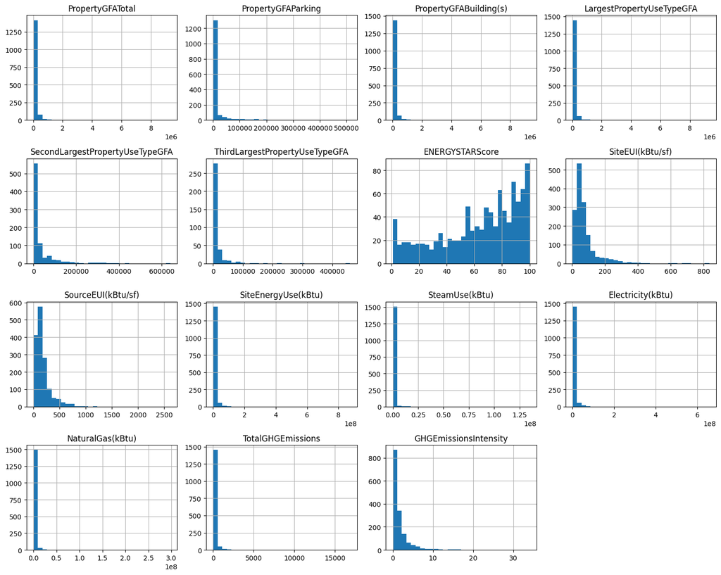

```python
data.hist(bins=30, figsize=(15,12))
plt.tight_layout()
plt.show()
```

```python
data.skew().sort_values(ascending=False) # asymértie des données sur la droite (sauf ENERGYSTARScore) ==> normaliser les données pour avoir une meilleure distribution
```

```
LargestPropertyUseTypeGFA         22.74
NaturalGas(kBtu)                  21.30
PropertyGFABuilding(s)            21.28
Electricity(kBtu)                 20.18
PropertyGFATotal                  18.79
SteamUse(kBtu)                    18.39
SiteEnergyUse(kBtu)               17.42
TotalGHGEmissions                 13.68
ThirdLargestPropertyUseTypeGFA     7.57
PropertyGFAParking                 5.01
SourceEUI(kBtu/sf)                 4.94
GHGEmissionsIntensity              4.55
SecondLargestPropertyUseTypeGFA    3.76
SiteEUI(kBtu/sf)                   3.68
ENERGYSTARScore                   -0.66
dtype: float64
```

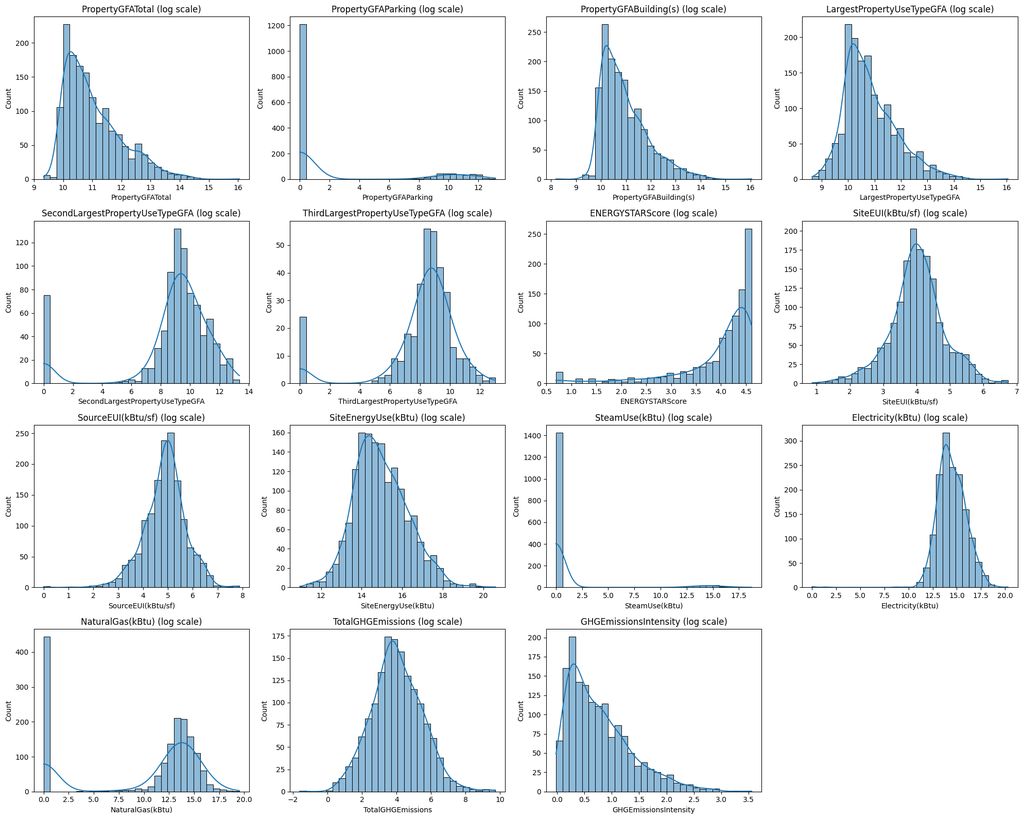

```python
cols = data.columns
n_cols = 4
n_rows = math.ceil(len(cols) / n_cols)

fig, axes = plt.subplots(n_rows, n_cols, figsize=(20, 4*n_rows))

axes = axes.flatten()  # pour itérer facilement

for i, col in enumerate(cols):
    sns.histplot(np.log1p(data[col]), bins=30, kde=True, ax=axes[i])
    axes[i].set_title(f"{col} (log scale)")

# Supprimer les axes vides si nombre impair
for j in range(i+1, len(axes)):
    fig.delaxes(axes[j])

plt.tight_layout()
plt.show()
```